# Data Analytics: Lebanese Disaster Relief Data

As a result of the August 4 explosion, the ongoing economic crisis, and the coronavirus pandemic, the Lebanese people are facing one of the most difficult living conditions in years. Relief efforts are being organized globally to help mitigate the burden on the Lebanese population and Lebanese citizens. The dataset we will study below contains information on communities in lebanon regarding their living conditions, medical and psychological health, and needs. Data was recorded by non-profits in Beirut and surrounding areas and the following report contains the documentation of the data cleaning.

The dataset contains 93 different variables, and 32,079 data entries. So, over 32,000 households were interviewed, with 93 questions each. Variables were numbered (from 1 to 93) for ease

## Importing Data and Loading Libraries

```python
import pandas as pd
import numpy as np
import matplotlib.pyplot as plt
import io
from google.colab import files
import scipy
from typing import Dict
from functools import reduce
```

```python
df = pd.read_excel("https://github.com/LynnWahab/ds_2021/blob/master/dataset/data.xlsx?raw=true", engine='openpyxl',)
# df = pd.read_excel("/content/data.xlsx", engine='openpyxl',)
df = df.iloc[0:32079]
```

## Variable Overview

```python
df.shape
```

```
(32079, 93)
```

The data contains:

- 93 different columns / variables of data
- 32079 rows or entries of data

```python
df.head(20)
```

|  | ID | Cadaster | Zone | Partner | introduction | Are you the Head of Household (i.e. the person responsible for providing for the people in this household)? | What is the respondant's relationship to HoH: | Do you currently live here in this apartment/house? | Location | Other, please specify | Year | Gender | Marital Status | Nationality of household | Other, please specify2 | Total number of members living now under the same roof (INCLUDING Head of Household) | Total number of members over age 60 | Total number of members between age 18 to 60 | Total number of members less than 18 | added_members | Are any of your family members pregnant or lactating? | Number of pregnant or lactating women | Does any of them need woman and child health? (Gynecological support, breastfeeding support, vaccination, etc.) | How many members | Are any of the children in the household separated or unaccompanied? | Number of separated minors (related to the family, i.e. nephew) | Number of unaccompanied minors (not related, i.e. orphan) | Does anyone have a chronic illness or critical medical condition? | Number chronically ill people/with critical medical conditions | … |
| --- | --- | --- | --- | --- | --- | --- | --- | --- | --- | --- | --- | --- | --- | --- | --- | --- | --- | --- | --- | --- | --- | --- | --- | --- | --- | --- | --- | --- | --- | --- |
| 0 | r9nwG | Achrafieh foncière | 57.0 | partner_other | yes | yes | NaN | yes | NaN | NaN | NaN | female | married | lebanese | NaN | 3.0 | 2.0 | 1.0 | 0.0 | NaN | no | NaN | NaN | NaN | NaN | NaN | NaN | no | 0.0 | … |
| 1 | zD63v | Achrafieh foncière | 57.0 | partner_other | yes | yes | NaN | yes | NaN | NaN | NaN | female | married | lebanese | NaN | 1.0 | 0.0 | 1.0 | 0.0 | NaN | no | NaN | NaN | NaN | NaN | NaN | NaN | yes | 1.0 | … |
| 2 | h8vyg | Achrafieh foncière | 57.0 | partner_other | yes | yes | NaN | yes | NaN | NaN | NaN | female | married | lebanese | NaN | 2.0 | 1.0 | 1.0 | 0.0 | NaN | no | NaN | NaN | NaN | NaN | NaN | NaN | no | 0.0 | … |
| 3 | HuRiz | Bourj Hammoud | 113.0 | UNHabitat | yes | yes | NaN | yes | NaN | NaN | 1957.0 | male | married | lebanese | NaN | 5.0 | 2.0 | 3.0 | 0.0 | NaN | no | NaN | NaN | NaN | NaN | NaN | NaN | no | 0.0 | … |
| 4 | jKeWE | Bourj Hammoud | 116.0 | UNHabitat | yes | no | wife/husband | yes | NaN | NaN | 1960.0 | female | married | lebanese | NaN | 4.0 | 1.0 | 2.0 | 1.0 | NaN | no | NaN | NaN | NaN | no | NaN | NaN | yes | 1.0 | … |
| 5 | S0GyQ | Bourj Hammoud | 108.0 | partner_other | yes | yes | NaN | yes | NaN | NaN | 1944.0 | female | widow | lebanese | NaN | 1.0 | 1.0 | 0.0 | 0.0 | NaN | no | NaN | NaN | NaN | NaN | NaN | NaN | yes | 1.0 | … |
| 6 | cu7OR | Achrafieh foncière | 57.0 | partner_other | yes | no | other | yes | NaN | NaN | 1957.0 | male | single | lebanese | NaN | 2.0 | 1.0 | 1.0 | 0.0 | NaN | no | NaN | NaN | NaN | NaN | NaN | NaN | yes | 1.0 | … |
| 7 | IBlsb | Achrafieh foncière | 57.0 | partner_other | yes | yes | NaN | yes | NaN | NaN | 1959.0 | male | single | lebanese | NaN | 1.0 | 0.0 | 1.0 | 0.0 | NaN | no | NaN | NaN | NaN | NaN | NaN | NaN | no | 0.0 | … |
| 8 | 7wnps | Achrafieh foncière | 57.0 | partner_other | no | NaN | NaN | NaN | NaN | NaN | NaN | NaN | NaN | NaN | NaN | 0.0 | NaN | NaN | NaN | NaN | NaN | NaN | NaN | NaN | NaN | NaN | NaN | NaN | 0.0 | … |
| 9 | aH2gc | Achrafieh foncière | 57.0 | partner_other | yes | yes | NaN | yes | NaN | NaN | 1959.0 | female | single | lebanese | NaN | 1.0 | 1.0 | 0.0 | 0.0 | NaN | no | NaN | NaN | NaN | NaN | NaN | NaN | yes | 1.0 | … |
| 10 | HTvtb | Bourj Hammoud | 116.0 | UNHabitat | yes | no | wife/husband | yes | NaN | NaN | 1967.0 | female | married | lebanese | NaN | 5.0 | 0.0 | 4.0 | 1.0 | NaN | no | NaN | NaN | NaN | no | NaN | NaN | no | 0.0 | … |
| 11 | haJny | Bourj Hammoud | 108.0 | partner_other | yes | no | other | yes | NaN | NaN | 1967.0 | female | widow | lebanese | NaN | 3.0 | 0.0 | 2.0 | 1.0 | NaN | no | NaN | NaN | NaN | no | NaN | NaN | yes | 1.0 | … |
| 12 | ujLS7 | Bourj Hammoud | 116.0 | UNHabitat | yes | no | other | yes | NaN | NaN | 1933.0 | female | single | ethiopian | NaN | 3.0 | 0.0 | 3.0 | 0.0 | NaN | no | NaN | NaN | NaN | NaN | NaN | NaN | no | 0.0 | … |
| 13 | 3q393 | Bourj Hammoud | 108.0 | partner_other | yes | no | wife/husband | yes | NaN | NaN | 1966.0 | female | married | syrian | NaN | 3.0 | 1.0 | 2.0 | 0.0 | NaN | no | NaN | NaN | NaN | NaN | NaN | NaN | yes | 2.0 | … |
| 14 | L2zcv | Achrafieh foncière | 53.0 | LRC | yes | yes | NaN | yes | NaN | NaN | 1937.0 | female | widow | lebanese | NaN | 1.0 | 1.0 | 0.0 | 0.0 | NaN | no | NaN | NaN | NaN | NaN | NaN | NaN | no | 0.0 | … |
| 15 | REYJf | Achrafieh foncière | 53.0 | LRC | yes | yes | NaN | yes | NaN | NaN | 1949.0 | female | single | lebanese | NaN | 1.0 | 1.0 | 0.0 | 0.0 | NaN | no | NaN | NaN | NaN | NaN | NaN | NaN | no | 0.0 | … |
| 16 | lsQPE | Achrafieh foncière | 53.0 | LRC | yes | yes | NaN | yes | NaN | NaN | 1952.0 | female | single | lebanese | NaN | 1.0 | 1.0 | 0.0 | 0.0 | NaN | no | NaN | NaN | NaN | NaN | NaN | NaN | no | 0.0 | … |
| 17 | kj0xY | Achrafieh foncière | 53.0 | LRC | yes | yes | NaN | yes | NaN | NaN | 1939.0 | female | married | lebanese | NaN | 2.0 | 1.0 | 1.0 | 0.0 | NaN | no | NaN | NaN | NaN | NaN | NaN | NaN | no | 0.0 | … |
| 18 | dE4aO | Achrafieh foncière | 53.0 | LRC | yes | yes | NaN | yes | NaN | NaN | 1959.0 | male | single | lebanese | NaN | 1.0 | 1.0 | 0.0 | 0.0 | NaN | no | NaN | NaN | NaN | NaN | NaN | NaN | no | 0.0 | … |
| 19 | U8Hx7 | Achrafieh foncière | 53.0 | LRC | yes | yes | NaN | yes | NaN | NaN | 1959.0 | female | married | lebanese | NaN | 4.0 | 0.0 | 2.0 | 2.0 | NaN | no | NaN | NaN | NaN | no | NaN | NaN | no | 0.0 | … |

20 rows × 93 columns

## Defining Helpful Functions

### Inspect(col)

Outputs the type and percentage of missing values in each column.

- For numericla columns (float64 or int64), it outputs the range, distribution of values
- For ordinal/ categorical columns, it outputs unique values

```python
def inspect(var: str):
  if df[var].dtypes == "O":
    print("------------------------------PRINT ALL AND TYPE-----------------------------------")
    #print(df[var])
    print("-------------------------------UNIQUE VALUES---------------------------------------")
    print(df[var].unique())
    print("---------------------------NUMBER OF UNIQUE VALUES---------------------------------")
    print(len(df[var].unique()))
    print("-------------------------NUMBER OF MISSING VALUES----------------------------------")
    print(df[var].isna().sum())
    print("-------------------------PERCENT OF MISSING VALUES---------------------------------")
    print(df[var].isna().sum()/len(df[var]))
    print("-------------------------DISTRIBUTION OF VALUES---------------------------------")
    df[var].value_counts(normalize=True).plot.barh()
    plt.show()
  elif df[var].dtypes == "float64" or df[var].dtypes == "int64" :
    print("------------------------------PRINT ALL AND TYPE-----------------------------------")
    #print(df[var])
    print("-------------------------------RANGE OF VALUES---------------------------------------")
    print("MIN", df[var].min())
    print("MAX", df[var].max())
    #Plot the distribution
    print("-------------------------NUMBER OF MISSING VALUES----------------------------------")
    print(df[var].isna().sum())
    print("-------------------------PERCENT OF MISSING VALUES---------------------------------")
    print(df[var].isna().sum()/len(df[var]))
    print("-------------------------DISTRIBUTION OF VALUES---------------------------------")
    hist = df[var].hist(bins=15, alpha=0.5)
    plt.title(var + " Distribution")
    plt.xlabel(var)
    plt.ylabel('Frequency')
```

### replaceWordSet(mistakenWords: set[str],replacement: str)

Replaces all the words in the mistakenWords set with the replacement string.

```python
def replaceWordSet(df, col, mistakenWords, replacement):
  uniqueVals = list(pd.unique(df[col]))
  for i in uniqueVals:
    if i in mistakenWords:
      df[col]= df[col].replace(i, replacement)
  return df[col]
```

### toLowerCase(df: pandas.Dataframe, col: str)

Replaces the values of the column named col with their lowercase string equivalent.

```python
def toLowerCase(df, col:str):
  uniqueVals = list(pd.unique(df[col]))
  for i in uniqueVals:
    if not pd.isnull(i):
      df[col]= df[col].replace(str(i), str(i).lower())
  return df[col]
```

```python
to_low = ['Are you the Head of Household (i.e. the person responsible for providing for the people in this household)?',
          'Is any member of your family identified with COVID-19 or experienced flu-like symptoms or have been in contact with a COVID-19 positive case in the previous 14 days?',
          'Does anyone have a physical or mental disability?',
          'Does any member of your family need immediate first aid support?',
          'Does any member of your family need chronic medications/healthcare?',
          'Does anyone have a chronic illness or critical medical condition?',
          'Nationality of household',
          'Marital Status',
          'Do your family has access to healthcare or medication since the incident?',
          'Gender',
          'Did you receive any assistance since the incident',
          'Have you or any household member damaged/lost any personal documents?',
          "Is there a migrant worker or domenstic helper living with this household? ",
          ]

# df[to_low] = df[to_low].apply(lambda x: x.astype(str).str.lower())
# bag = set(["Wife", "wife"])
# df["What is the respondant's relationship to HoH:"] = replaceWordSet(df, "What is the respondant's relationship to HoH:", bag, "wife/husband")
```

## scoreOptions(keywords: List[str], lookupTable: Dict[str, int])

Replaces each value in column named col with the sum of the scores of different comma and underscode separated values, each keyword's score is provided in the lookupTable dictionary.

```python
def compute_score(keywords, lookupTable):
  score = 0
  for keyword in keywords:
    if lookupTable.get(keyword):
      score+=lookupTable.get(keyword)
  return score
def scoreOptions(df, col, lookupTable: Dict[str, int]):
  column = list(df[col])
  #Compute total score from set of keywords in the column example: (glass, frames)
  split_by_comma_then_underscore = lambda string:set([entry for term in string.split(",") for entry in term.split("_") ]) if not pd.isnull(string) else string
  column = map(split_by_comma_then_underscore, column)
  scores = [keywords if pd.isnull(keywords) else compute_score(keywords, lookupTable)  for keywords in column]
  df[col] = scores
  return df[col]
```

```python
def select_options(col):
  for index, row in df.iterrows():
    if (type(row[col])!= float):
      row[col] = row[col].split(",")
```

# AREA

## Variable 1: Cadaster

- The unique values is only 17, and so we will not divide into categories
- Percent of missing values (5%) is low

```
------------------------------PRINT ALL AND TYPE-----------------------------------
-------------------------------UNIQUE VALUES---------------------------------------
['Achrafieh foncière' 'Bourj Hammoud' 'Bachoura foncière' 'Rmeil foncière'
 'Saifi foncière' 'Mdaouar foncière' nan 'Zqaq el-Blat foncière'
 'Mina el-Hosn foncière' 'Ras Beyrouth foncière' 'Mazraa foncière'
 'Sinn El-Fil' "Marfa' foncière" 'Msaitbe foncière' 'Furn Ech-Chebbak'
 'Beirut Central District' 'Aain el-Mraisse foncière']
---------------------------NUMBER OF UNIQUE VALUES---------------------------------
17
-------------------------NUMBER OF MISSING VALUES----------------------------------
1606
-------------------------PERCENT OF MISSING VALUES---------------------------------
0.05006390473518501
-------------------------DISTRIBUTION OF VALUES---------------------------------
```

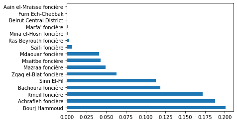

```python
inspect("Cadaster")
# print("Meaning: ")
```

## Variable 2: Zone

- Note sure what this variable means
- Zone (numerical values) between 0 and 187
- Only around 5% missing values

```
------------------------------PRINT ALL AND TYPE-----------------------------------
-------------------------------RANGE OF VALUES---------------------------------------
MIN 0.0
MAX 187.0
-------------------------NUMBER OF MISSING VALUES----------------------------------
1571
-------------------------PERCENT OF MISSING VALUES---------------------------------
0.04897284828080676
-------------------------DISTRIBUTION OF VALUES---------------------------------
```

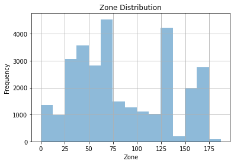

```python
inspect("Zone")
```

# RECORDING

## Variable 3: Partner

Partner denotes the organization affiliated with the interview that recorded each entry.

- The percent of missing values is less that 2%.
- Spelling is correct
- Over 60% of records were collected by the Lebanese Red Cross

```
------------------------------PRINT ALL AND TYPE-----------------------------------
-------------------------------UNIQUE VALUES---------------------------------------
['partner_other' 'UNHabitat' 'LRC' 'Intersos' 'Save the Children' 'CWW'
 'Medair' 'PCPM' 'NRC' 'UNHCR' 'Leb-Relief' 'Solidarite' 'WFP' 'Unicef'
 'Acted' 'Concern' 'PU AMI' 'AAH' 'IOM' 'Nawaya' 'Lebanese_University'
 'Arcenciel' nan 'radi jarouch' 'Caritas']
---------------------------NUMBER OF UNIQUE VALUES---------------------------------
25
-------------------------NUMBER OF MISSING VALUES----------------------------------
612
-------------------------PERCENT OF MISSING VALUES---------------------------------
0.019077901430842606
-------------------------DISTRIBUTION OF VALUES---------------------------------
```

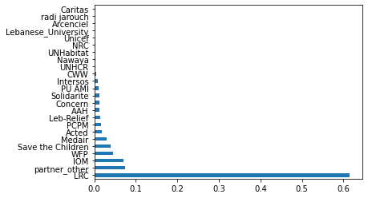

```python
inspect("Partner")
```

## Variable 4: Introduction

Unsure what this variable means.

- Very low percent of missing values

```
------------------------------PRINT ALL AND TYPE-----------------------------------
-------------------------------UNIQUE VALUES---------------------------------------
['yes' 'no' nan]
---------------------------NUMBER OF UNIQUE VALUES---------------------------------
3
-------------------------NUMBER OF MISSING VALUES----------------------------------
7
-------------------------PERCENT OF MISSING VALUES---------------------------------
0.00021821129087565074
-------------------------DISTRIBUTION OF VALUES---------------------------------
```

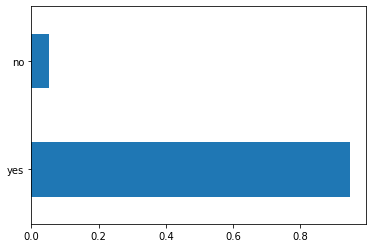

```python
inspect("introduction")
```

# INTERVIEWEE

## Variable 5: Are you the Head of Household (i.e. the person responsible for providing for the people in this household)?

```
------------------------------PRINT ALL AND TYPE-----------------------------------
-------------------------------UNIQUE VALUES---------------------------------------
['yes' 'no' nan]
---------------------------NUMBER OF UNIQUE VALUES---------------------------------
3
-------------------------NUMBER OF MISSING VALUES----------------------------------
1662
-------------------------PERCENT OF MISSING VALUES---------------------------------
0.05180959506219022
-------------------------DISTRIBUTION OF VALUES---------------------------------
```

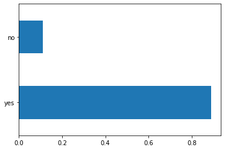

```python
df["Are you the Head of Household (i.e. the person responsible for providing for the people in this household)?"] = toLowerCase(df, "Are you the Head of Household (i.e. the person responsible for providing for the people in this household)?")
inspect("Are you the Head of Household (i.e. the person responsible for providing for the people in this household)?")
```

## Variable 6: What is the respondant's relationship to HoH:

```
------------------------------PRINT ALL AND TYPE-----------------------------------
-------------------------------UNIQUE VALUES---------------------------------------
[nan 'wife/husband' 'other' 'daughter/son']
---------------------------NUMBER OF UNIQUE VALUES---------------------------------
4
-------------------------NUMBER OF MISSING VALUES----------------------------------
28744
-------------------------PERCENT OF MISSING VALUES---------------------------------
0.8960379064185292
-------------------------DISTRIBUTION OF VALUES---------------------------------
```

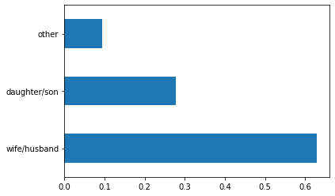

```python
#make lowercase
df["What is the respondant's relationship to HoH:"] = toLowerCase(df, "What is the respondant's relationship to HoH:")
df["What is the respondant's relationship to HoH:"] = toLowerCase(df, "What is the respondant's relationship to HoH:")
df["What is the respondant's relationship to HoH:"] = df["What is the respondant's relationship to HoH:"].replace('wife', 'wife/husband')
inspect("What is the respondant's relationship to HoH:")
```

## Variable 7: Do you currently live here in this apartment/house?

- Almost all respondants (interviewees) were living in the current household they are interviewing for.
- Around 5% of values are missing for this column.

```
------------------------------PRINT ALL AND TYPE-----------------------------------
-------------------------------UNIQUE VALUES---------------------------------------
['yes' nan 'no']
---------------------------NUMBER OF UNIQUE VALUES---------------------------------
3
-------------------------NUMBER OF MISSING VALUES----------------------------------
1663
-------------------------PERCENT OF MISSING VALUES---------------------------------
0.051840768103743884
-------------------------DISTRIBUTION OF VALUES---------------------------------
```

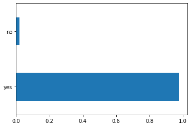

```python
df["Do you currently live here in this apartment/house?"] = toLowerCase(df, "Do you currently live here in this apartment/house?")
inspect("Do you currently live here in this apartment/house?")
```

## Variable 8,9: Location | Other, please specify

LOCATION

- 'Other' only makes up around 50% of Location values
- NaN for 'other' column is around 70%
- So there must have been some errors in recording or some people who weren't represented.
- We checked and found that no rows have a location value for both columns. Some rows have 'other' and NaN. Many rows have NaN for both columns. 12324 values are missing for both.

OTHER, PLEASE SPECIFY

- We categorized items into locations to make sure we got rid of spelling mistakes.
- It still needs some more work.

```
------------------------------PRINT ALL AND TYPE-----------------------------------
-------------------------------UNIQUE VALUES---------------------------------------
[nan 'Achrafieh' 'Bachoura' 'Rmeil' 'Beirut Central District' 'Saifi'
 'Mdaouar' 'other' 'Zqaq el-Blat' 'Marfa' 'Mina el-Hosn']
---------------------------NUMBER OF UNIQUE VALUES---------------------------------
11
-------------------------NUMBER OF MISSING VALUES----------------------------------
12324
-------------------------PERCENT OF MISSING VALUES---------------------------------
0.38417656410735995
-------------------------DISTRIBUTION OF VALUES---------------------------------
```

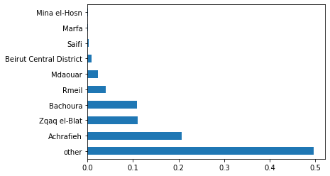

```python
df["Location"] = df["Location"].replace('ashrafieh', "Achrafieh")
df["Location"] = df["Location"].replace('Mina Elhosn', "Mina el-Hosn")
df["Location"] = df["Location"].replace('Zqaq Elblat', "Zqaq el-Blat")

inspect("Location")
```

```
------------------------------PRINT ALL AND TYPE-----------------------------------
-------------------------------UNIQUE VALUES---------------------------------------
[nan 'gemmayze' 'Khandak el-Ghamee2' 'basta tahta' 'karm zaytoun'
 'Bourj Hammoud' 'Bachoura' 'al zahrawi' 'Zqaq el-Blat' 'carantina'
 'Mar Mkhayel' 'Nabaa' 'ras lnabah' 'Sinn El-Fil' 'برج حارة حارة صادق'
 'mar3ach' 'arax' 'شارع العريض' 'شارع طرابلس' 'شارع طرابلس قسيس الدورة'
 'شارع ارمينية' 'dora' 'الدورة شارع ارمينيا' 'شارع عيد'
 'شارع الاخطل جنب عقيل اخوان قرب شلالا' 'salim slem' 'nigeria' 'centrale'
 'شارع عقيل' 'شارع ارمينيا' 'قرب big sale' 'جانب مكتب الشرق الاوسط'
 'بناية فلفلة جانب مكتب السفريات' 'جانب مكتب السفريات' 'بناية حميرة'
 'بناية حبيقة' 'بناية سوفاك' 'بناية هدلة مقابل تمثال الشهداء'
 'بناية محمود نجم الدين جانب تمثال الارمن' 'جانب تمثال الارمن'
 'بناية محمود نجم الدين' 'شارع اضنا بناية جعارة' 'بناية جعارة شارع اضنا'
 'شارع اضنا' 'بناية ميساك بادريان مقابل محل الخضار'
 'بناية جوزيف ابي راشد جانب نادي الارمن' 'miled charar' 'le mall area'
 'قرب شركة المياه' 'قرب ركة المياه' 'قرب سوبر ماركت كوان ماركت'
 'قرب شرمة المياة' 'قرب شركة المياة' 'قرب سوبر ماركت كوان'
 'قرب كوان ماركت' 'sheild' 'تامارزا فرن القبو' 'شركة المياه'
 'قرب مؤسسة المياه' 'قرب شركة المياه منطقة ٦شارع ٧٩'
 'قرب شركة المياه / كوان ماركت' 'شارع كوان ماركت' 'acf' 'قري شرمة المياة'
 'قرب نادي الارمن' 'خلف كنيسة ماربوسف' 'خلف كاريتاس كنيسة مار يوسف'
 'قرب صيدلية ديب' 'قرب كنيسة مار يوسف كاريتاس' 'كاريتاس مار يوسف'
 'شارع سانت ريتا' 'شارع صادر/ بناية أنّا صاندريان'
 'chere3 mar yousef bineyet anna sanedrian' 'شارع مار يوسف' 'شارع طمرزا'
 'شارع الصادر' 'chere3 toumarza' 'bauchrieh' 'port area' 'beirut'
 'jdeideh' 'مقابل مؤسسة الهراوي' 'stephanie joey' 'badawi street'
 'badaqi street' 'borj el barajneh' 'tatiana gerges' 'Furn Ech-Chebbak'
 'bourn' 'zarif' 'aisha bakkar' 'cornich el naher' 'msytbe salen slem'
 'Tarik Jdide' 'elias el achkar' 'barbour' 'Mazraa' 'basta'
 'borj abi haidar' 'basta faw2a' 'sodico' 'mdawar' 'ashrafieh'
 'cornich el mazraa' 'bchara al khoury' 'bechoura' 'badawi' 'hématie'
 'tabaris' 'getaoui' 'watwet' 'biaquout' 'bsaba' 'hotel dieu' 'delta'
 'sheildteam7' 'msaitbe' 'ain el mrayse' 'anwayri sidi hassan street'
 'bidawe street' 'jedayde' 'اشرفية - بناية باولي الطابق ٦'
 'شارع أرمينيا جامع الخضر جنب كنيسة' 'رميل' 'كورنيش النهر'
 'بدوي-كورنيش النهر - شارع خليل البدوي-بناية داوود سعدو' 'rmeil'
 'فوج الاطفأ' 'البسطا التحتا شارع فتح الله' 'شارع الزهراوي بناية عيسى'
 'شارع فتحالله' 'بشارة الخوري' 'kaskas' 'kobayat' 'salim sleim'
 'manta2et l hekme' 'ashou3' 'kashou3' 'skandar farah' 'je iraqi' 'barbor'
 'sad el bouchrieh' 'الزريف' 'spears' 'hamra' 'bir hasan' 'badaoui area'
 'badawe' 'تلت الخلاط' 'خلدة' 'النويري' 'mar elias' 'port' 'wetwet'
 'badaro' 'haret hreik' 'bshara elkhoury' 'nouwayre'
 'al malla chare3 bani oumayya' 'mhamra' 'armenia' 'dar fatwa' 'تلمزرعة'
 'moudawar' 'ras beirut' 'bchara khoury' 'hekme' 'jdaide' 'hazmieh'
 'dahyeh' 'jnah' 'شياح' 'صائية الجنزير' 'كترمايا' 'batrakiyeh']
---------------------------NUMBER OF UNIQUE VALUES---------------------------------
175
-------------------------NUMBER OF MISSING VALUES----------------------------------
22294
-------------------------PERCENT OF MISSING VALUES---------------------------------
0.6949717883973939
-------------------------DISTRIBUTION OF VALUES---------------------------------
```

[figure not shown]

```python
#Different spelling for same location. For example: borj, burj, bourj, Burj, Birj, Bourej/ Sin el fil, Sen El Fel, Sin lfill/ spelling in arabic
df["Other, please specify"] = df["Other, please specify"].str.strip()
df["Other, please specify"] = df["Other, please specify"].replace('\s+', ' ',regex=True)
df["Other, please specify"] = toLowerCase(df, "Other, please specify")
replacement_bags_pairs = {
                          "Sinn El-Fil": set(['sinn el-fil','sin el fil', 'son el fil', 'sen el', 'sin el fil', 'son el fil', "sin el fel", 'sin lfil' ,'sin al fil', 'sen l fil' ,'sin l fil','ain el fil', 'sin  fil', 'sin el fel', 'sinn el fil' ,'sinn ek fil', 'sinlfil', 'sein al fiel' ,'sin el feil' ,'sinel fil' ,'sin 3l fil', 'sin el phil', 'sun el fil' ,'sin lfel' ,'sin el fiñ', 'sin fil', 'sin' ,'sin el fild', 'sin el fol' ,'sin dl fil', 'sin el il', 'sin el filq' ,'sin el filp', 'sin e fil', 'sil el fil', 'sin elf fil', 'sin el til', 'sin el fin','sinel','sinelfi', 'sib el fil', 'zin el fil' ,'sin rl fil', 'sin  el fil', 'sin lfill', 'sen lfill', 'sin el fil', 'sinelfil', 'sin elfil', 'sen el fil', 'سن الفيل', 'sjn el fil', 'si el fil', 'sin el fill', 'sin el urgent', 'sin el fill', 'سن لفيل', ]),
                          "Bourj Hammoud": set(['قرب كوان ماركت','قرب سوبر ماركت كوان ماركت','قرب سوبر ماركت كوان' ,'bourj hammoud','burj hamoid','borge hamoud','bourj hamoud', 'borj hammoud', 'borj hamoud', 'برج حمود شارع كيليكيا', 'burj hammoud', 'برج حمود', 'برج حمود شارع حمود', 'شارع كيليكيا برج حمود', 'برج حمود شارع كيليكا', 'burj hammoud', 'برج حمود', 'برج حمود شارع حمود', 'شارع كيليكيا برج حمود', 'bourh hammoud', 'burj hamoud', 'برج حمود شارع كيليكا', 'burj hamud', 'bourj hammous', 'birj hammoud', 'bourej hamoud', 'bourj hammou', 'bourej hammoud', 'borj hmoud', 'برج حمود حارة صادر', 'برج حمود شارع صاد', 'burj hamud', 'bourj hammous', 'birj hammoud', 'برج حم', 'birj hamoud', 'born hammoud', 'bourk hamoud','bourj hammouf', 'bourjhamoud', 'bouj hamoud', 'berhamoud', 'bourj hammoud, maraash', 'برج الحمود', 'berj hamoud arax', 'bourj hammoue',  'berj hamoud', 'bourjhammoud', 'bourn hammoud', 'bourj hammoud, arax', 'برج حمود.', 'burj hamod', 'berj hamouf', 'berj hammoud', 'burj hamoood', 'borj hamod', 'burj hammod', 'bourj', 'borj hammod', 'borj hamood', 'bourj hammoid', 'burjhammod', 'burj hammud', 'borj hammoud0', 'biurj hammoud', 'barj hamoud', 'borj hammoid', 'borj hamud', 'barjhammod', 'bourj hammouc', 'burjj hamud', 'bour hammoud', 'borj houmd', 'borjhamoud', 'barjhamoud', 'burj hammous', 'burj hanmoud', 'borej hamoud', 'berej hammoud', 'bourjj hamoud', 'burj hamouf', 'burj barajne', 'both hammoud', 'berej hammud', 'bouri hammoud', 'borjhamud', 'berej hamoud', 'boroj hammoud', 'bourj hammoud zone 122', 'borj hamoud near mar youssef church', 'borj hammoud haret sader street', 'borj hammoud near mar youssef church', 'bork hammoud', 'bork hamoud', 'borj hammoud', 'bourj hammond', 'borj hamouud', 'bourj hammoud haret sader street', 'borj hammoud , mar youssef street', 'boutj hammoud', 'burj hamdoud', 'borj hammoud ,haret sader street', 'borj hammoud haret sader st', 'borj hammoud mar youssef church''bourhamoud', 'bourj hsmmoud', 'borj hammud', 'bej hamoud', 'berej hamouf', 'bourj hammoud l', 'borj hamoid', 'bofrj hamoud', 'bouj hammoud', 'borj hammoud armeina street', 'borj hampud', 'borj hamooud', 'borj hammoud adana street', 'borj hammoud dora street', 'borj hammoud , adana street', 'borj hammoud adana', 'borj hammoud, adana street', 'bonrj hammoud', 'borjhammud', 'boj hamud', 'bourj hanmoud', 'burj hammoud ya', 'borj hammoud armenia street', 'borj hammous , armenia street', 'bourj hammoud0', 'borj hammoud , armenia street', 'bourej hamou', 'borj hammoud, lebanese water company street', 'borj hammoud ,lebanese water company', 'boroj hamoud', 'bourj hamood', 'brj hammoud', 'burj hammoud ya te to un', 'borj hmmoud', 'borj hammoud haret sader', 'bourja hammoud', 'bourj hammoud zone 121', 'bourj hammmoud', 'bourj hammoud - armenian red cross', 'bourj hammoud - near armanian red cross', 'borj hammoud near armenian red cross', 'bourj hamouf', 'burj hamoudi', 'borj hanmoud', 'bprj hammoud', 'berj hamud', 'burj hammiud', 'burj hanoud', 'burj hsmud', 'برج حمود شارع صادر', 'برج حمود جارع كيليكيا', 'برج حمود شارع مادونا', 'برج حمود شارع كنيسة مار يوسف', 'برج حمود شارع كويسة مار يوسف', 'برج حمود _شارع مادونا', 'برج حمود شارع السنترال', 'برج حمود جنب السنترال', 'برج حمو', 'برج الحمو', 'برج حمود/ شارع طرابلس', 'بىج حمود', 'برج حمودط', 'برج حمود منطقة شارع ٧٦ الطابق الارضي قرب شركة المياه', 'برج حمود/ شارع طومرزا', 'برج حمود/ شارع طمورزا','برج حمود/ شارع الصادر', 'borj hammoud,haret saber street', 'borj hammoud mar youssef church', 'bourhamoud', 'يرج حمود', 'berj hammof', ]),
                          "Zqaq el-Blat": set(['زقيق البلاط','zqaq el-blat','zkak l blat','z2a2 al blat','z2a2 al blad', 'zkak el blat','zkak al blat' 'z2a2 al blad', "zkak blat", "zkak l blat", "zkak lblat", 'z2a2 al blad' 'z2a2 al blat']),
                          "Furn Ech-Chebbak": set(["furn l chebbek",'furn el chebak','furn ech-chebbak','furn l chebbek','furn el chebak']),
                          "Bachoura": set(['باشورا','bachoura',"الباشورة"]),
                          'Mazraa': set(['مزرعة','mazraa','mazra3a','mazras','مزرعه','mazraq','maraa','mazrra','al mazraa','mazeaa','marzraa']),
                          "Mar Mkhayel": set(['مار مخايل بناية الراهب','mar mkhayel','مار مخايل','مار مخاييل','mar m5ayil rabat street', 'mar mikheal', 'mar mkhayel churche', 'mar mkhayel', 'mar m5ayel', 'mar mkhyel', 'mar mkheyal', 'mar mkhail', 'mar mkail', 'mar mhkayel', 'marmkhayel', 'mar mkhael', 'mar mkhayl', 'mar mikeal', 'marmkhyael', 'mar mkhayal', 'marmkhayl', 'mar mkheael', "mar mkheyeil", "مارمخايل", "مارم مخايل", 'mar m5ayel' 'mar mkhyel', "mar mikhael", "mar mikhaiel"]),
                          "Tarik Jdide": set(['tari2 jdide', 'طريق الجديدة','tarik jadide','taree2 jdede','tari2 jdide , bohsali', 'tarik jdide', 'tariq jadede', 'tariq jdede', 'tari2 jdideh']),
                          "Khandak el-Ghamee2": set(['khandak el-ghamee2','khandak el ghamee2', 'الخندق الغميق','khanda2', 'khandaa',"khandak el khame2", "خندق الغميق", 'khandak el ghamee2', 'khanda2 gham2', 'khanda2 ghami2', 'ghanda2 ghami2', 'khnda2', 'khanda2 l ghami2', 'khandak ghamik', 'khandak', 'khanda2 lghamii', 'khandk', 'khanda2 l ghamii', 'khandaa l ghamii']),
                          np.nan: set(['1',"0", 'no','.', 'iom','not mention']),

                          "gemmayze": set(['gemeyze',"gemmayze", "gemeyzeh", "jenayzeh", "gemaize", 'gemmayaze', 'gemmeyaze', 'jemmayze', "gemayze", "jemayze", "jemayzeh", "jemmayzeh", 'gemmayzeh near redcross 202', 'gemayzeh', 'جميزة', 'gemmayzeh near rc 202']),
                          "basta tahta": set([ 'بسطى التحتى','فوج الاطفأ' 'البسطا التحتا شارع فتح الله', 'البسطة التحتى','basta el tahta','basta al tahta bachoura','basta tahta fathallah street',"البسطة التحتا", "بسطة التحتة", 'basta tahta','basar el tahta', 'basra el tahta', 'basta l tahta', 'bosta al tahta', 'basta al tahta', 'basra l tahta', 'basta al tahta fathallah street','bssta','nasta l tahta','bast tahta','basta-al tahta']),
                          "karm zaytoun": set(['كرم الزيتون','karem al zaytoun',"karm el zeitoun",'karm zaitoun','karem l zaytoun','karm el zaytoun','karm e zaytoun','karam el zaytoun','karem l zeitoun','karam zaytoun']),
                          "carantina": set([ 'كارنتينا شارع الرهبان مقابل الرابطة المارونية بناية عبدو','كارنتينا' ,'الكرنتينه', 'كرنتيته','karantona','karentina','karangina','karatina','karantin','quarantin', 'karntina', 'quarantina', 'quarantine', 'carantina', 'qurantine', "karantina", 'karntina' 'quarantina' 'quarantine', 'karantine', 'karanteena', 'karnteena', 'karsntins', 'كرنتينا', 'karamteena', 'karantena', 'karnatina', 'karantinz', 'krntina', 'ka4antina']),

                          "ras lnabah": set(['ras al nabeh','ras el nabeh','rass nabaa','ras nabaa','ras al nabea','ras al nabeh','ras al nabaa','ras l nabeh', 'ras lnabeh', 'ras nabeh', 'ras elnabaa', "ras nabe3", "ras nabea",  'ras el nabee']),
                          "mar3ach": set(['maraash', 'مرعش']),
                          "dora": set(['الدورة','dora', 'dawra']),
                          "borj el barajneh": set(['borj al barajne', 'borj al barajni', ]),
                          "borj abi haidar": set(['برج ابي حيدر', 'برج ابو حبدر', 'borj abj haidar','borj abou haydar','berj abu haydar','burj abi haidar','burj abi haidet','boroj abi haidar','burj abi hayder','berj abi haidar', 'burj abou haydar', 'bourj abi haidar', "برج اب حيدر", 'bourj abi haydar', 'bourj abj haidar', "برج ابو حيدر", "borj abu haidar", 'burj haydar', 'burj abi haydar']),
                          "cornich el naher": set(['cornich al naher']),
                          "msaitbe": set(['المصيطبة', 'اامصيطبي','msaitbe','msaytbeh mar elias','mousaitbeh karkol el druz','moussaitbeh', 'mousseitbeh', 'msaibte', 'msaibti', 'msaitbe', 'مصيطبي', 'المصيطبى', 'المصيطبه', 'msaitbi', 'مصيطبة', 'msaytbi, saeb slam street', 'msaytbi semaan street, hashem meghnye building', 'maaytbe', 'mousaitbeh','masitbe','mseitbeh', 'msaitbii', 'mseibeh', 'mseitbe', 'moaaitbe', 'mositbe', 'moustaitbeh', 'musaitbeh', 'masitbeh', 'msaybeh', 'mouseitbeh', 'mousaitbah', 'المصيطبي١', 'mousaitibeh', 'msaythe', 'mousaytbe', 'mosaytbe', 'mosaytbeh', 'misaytbeh', 'mousqytbe', 'mosaitbeh','المسيطبة', 'mseibe', 'mosaitbe', 'mosaibte', 'المصيطبي', 'msaytbi', 'msytbe', 'msaitbeh', 'مصيطبه', 'msaytbe', 'msaytbeh', 'mousaitbe']),
                          'getaoui': set([ 'جعيتاوي','الجعيتاوي','getaoui', 'geitawa', 'getawi', 'geatawi', 'jeatawi', 'j3eytewe', 'j3itawi', 'geutawi sher3 asho3', 'geitawi', 'jeitawi', 'geitaoui', 'geoutawi', 'geatawi', 'jeatawi', 'j3eytewe', 'j3itawi', 'jeitewe', 'j3itewe','joutewi', 'gitawi', 'joutewe', 'j3itewi', 'jetawe', 'joueitawi', 'geytaoi', 'geotaoui']),
                          'basta faw2a': set(['البسطة الفوقا، نزلة المخفر' ,'بسطا الفوقة','البسطة الفوقى', 'basta faw2a','البسطة الفوقا', 'basta al fawka', 'basta fawqa','basta fawka', 'basta el faw2a','basta al fawka' 'basta fawqa','al basta al fawka','البسطا الفوقا', 'mazraa,basta al fawka' ,'basta l fawka']),
                          'salim sleim': set(['salim slam','salim salam','salem slam', 'سليم سلام', 'salim slem' ]),
                          "basta": set([ 'اابسطة','البسطة','basta','baata', 'bassta', 'al basta']),
                          "Nabaa": set(['النبعة' , 'nabaa', 'نبع' , 'nabaaa' ,'النبعا']),
                          "Centrale": set(['شارع السنترال', 'شلرع السنترال', 'قرب سنترال اوجيرو', 'شارع السنترال بناية أداميان', 'شارع السنترال بناية اتاميان','مبنى حميرة شارع السنترال','شارع السنترال اضنا بناية سليم غانم', 'شارع السنترال بناية داغر حايك','بناية السنترال', 'بناية مهدي علي الحاج شارع السنترال', 'شارع السنترال جانب تمثال الارمن', 'شارع السنترال بناية محمود نجم الدين جانب نمثال الشهداء', 'بناية محمود نجم الدين جانب تمثال السنترال', 'جانب السنترال بناية محمود نجم الدين' ]),


                          }

for replacement in replacement_bags_pairs.keys():
  wordBag = replacement_bags_pairs[replacement]
  df["Other, please specify"] = replaceWordSet(df, "Other, please specify", wordBag, replacement)

inspect("Other, please specify")
```

```python
df1 = df[["Location", "Other, please specify"]]
pd.set_option('display.max_rows', df.shape[0]+1)

df1 = df1[df1['Other, please specify'].isnull()]
df1 = df1[df1['Location'].isnull()]

len(df1)
```

```
12324
```

```python
len(pd.unique(df["Other, please specify"]))
```

```
176
```

## Variable 10: Year

- Year of birth of interviewee.
- Only 8% of values are missing.
- The values are normally distributed and reasonable (except 1906).
- This outlier will be dealt with soon

```
------------------------------PRINT ALL AND TYPE-----------------------------------
-------------------------------RANGE OF VALUES---------------------------------------
MIN 1906.0
MAX 2004.0
-------------------------NUMBER OF MISSING VALUES----------------------------------
2583
-------------------------PERCENT OF MISSING VALUES---------------------------------
0.08051996633311512
-------------------------DISTRIBUTION OF VALUES---------------------------------
```

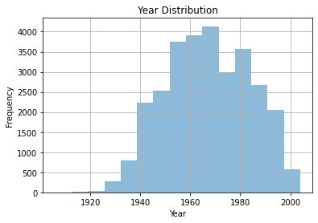

```python
inspect("Year")
```

## Variable 11: Gender

```
------------------------------PRINT ALL AND TYPE-----------------------------------
-------------------------------UNIQUE VALUES---------------------------------------
['female' 'male' nan 'other' 'prefer_not_to_say']
---------------------------NUMBER OF UNIQUE VALUES---------------------------------
5
-------------------------NUMBER OF MISSING VALUES----------------------------------
1669
-------------------------PERCENT OF MISSING VALUES---------------------------------
0.05202780635306587
-------------------------DISTRIBUTION OF VALUES---------------------------------
```

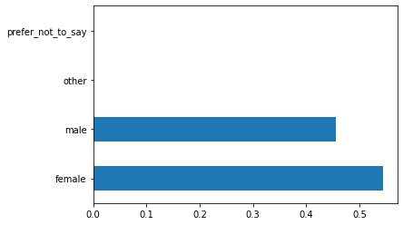

```python
df["Gender"] = toLowerCase(df, "Gender")
inspect("Gender")
```

## Variable 12: Marital Status

```
------------------------------PRINT ALL AND TYPE-----------------------------------
-------------------------------UNIQUE VALUES---------------------------------------
['married' 'widow' 'single' nan 'married_separated_from_partner']
---------------------------NUMBER OF UNIQUE VALUES---------------------------------
5
-------------------------NUMBER OF MISSING VALUES----------------------------------
1669
-------------------------PERCENT OF MISSING VALUES---------------------------------
0.05202780635306587
-------------------------DISTRIBUTION OF VALUES---------------------------------
```

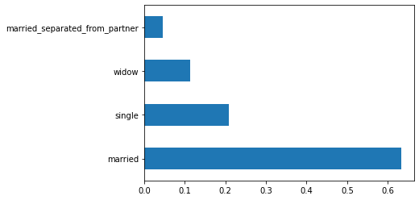

```python
#Make lower
df["Marital Status"] = toLowerCase(df, "Marital Status")
df["Marital Status"] = df["Marital Status"].replace('married_living_with_partner', 'married')
df["Marital Status"] = df["Marital Status"].replace('living_with_partner', 'married')
inspect("Marital Status")
```

# HOUSEHOLD HEALTH, AGE, MEDICAL CONDITION

## Variable 13,14: Nationality of household | Other, please specify2

- Only 5% of values are missing from this, and less that 5% are 'other'.
- It might be possible to eliminate the 'other, please specify' column.
- Over 80% of interviewees are Lebanese.
- For the 'other' column, over 98% of values are missing

```
------------------------------PRINT ALL AND TYPE-----------------------------------
-------------------------------UNIQUE VALUES---------------------------------------
['lebanese' nan 'ethiopian' 'syrian' 'other' 'iraqi' 'bangladesh'
 'palestinian' 'sudanese' 'philippines']
---------------------------NUMBER OF UNIQUE VALUES---------------------------------
10
-------------------------NUMBER OF MISSING VALUES----------------------------------
1770
-------------------------PERCENT OF MISSING VALUES---------------------------------
0.05517628354998597
-------------------------DISTRIBUTION OF VALUES---------------------------------
```

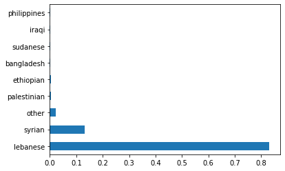

```python
#Make lower and also "lebanese " vs "lebanese"
df["Nationality of household"] = toLowerCase(df, "Nationality of household")
df["Nationality of household"] = df["Nationality of household"].str.strip()
df["Nationality of household"] = df["Nationality of household"].replace('lebanese ', 'lebanese')
inspect("Nationality of household")
```

```
------------------------------PRINT ALL AND TYPE-----------------------------------
-------------------------------UNIQUE VALUES---------------------------------------
[nan 'sri lankan' 'finland' 'egyptian' 'french' 'chinese' 'italian'
 'japanese' 'iranian' 'algerian' 'jordanian' 'american' 'swiss' 'greek'
 'cameroonian' 'malagasy' 'kenyan' 'nigerian' 'armenian' 'arab'
 'madagascar' 'turkish' 'sudanese' 'bolimia' 'kuwaiti' 'thai'
 'sierra leonean' 'oganda' 'senegalese' 'ethiopian' 'moroccan'
 'bangladeshi' 'lebanese' "côte d'ivoire" 'canada' 'british' 'syrian'
 'belgian' 'australian' 'german' 'spanish' 'slovako' 'pakistani' 'georgia'
 'romanian' 'indian' 'russian' 'venezuella' 'taiwan' 'philipines'
 'kurdish' 'brazilian' 'canadian' 'ghana' 'polish' 'danish' 'ukraine'
 'netherlands' 'yemeni' 'they have no nationality' 'palestinian' 'None'
 'Under Study' 'somali']
---------------------------NUMBER OF UNIQUE VALUES---------------------------------
64
-------------------------NUMBER OF MISSING VALUES----------------------------------
31471
-------------------------PERCENT OF MISSING VALUES---------------------------------
0.981046790735372
-------------------------DISTRIBUTION OF VALUES---------------------------------
```

[figure not shown]

```python
#Written in arabic
df["Other, please specify2"] = df["Other, please specify2"].str.strip()
df["Other, please specify2"] = toLowerCase(df, "Other, please specify2")
replacement_bags_pairs = {"lebanese": set(['sin el fil', 'مزرعه', 'سن الفيل', 'المصيطبي', 'mousaytbe']),
                          "sri lankan":set(["سيرلنكا", "سيريلانكا", "sirilinka", "syrelinka", 'serilanka', 'serlankap', 'srilankan', 'sirilanka', 'sirlanka', "sri lanka" ]),
                          "armenian": set(["ارمنية", 'armani', 'ارمني', 'أرمني', 'ارمنب', 'armanian', 'arminia']),
                          "madagascar": set(["madaghashkar", 'madagasikara', 'madagaskar']),
                          "egyptian": set(["egypt", 'egypt', 'egyption', 'egypian', 'eygption', 'egypthian', 'egytian', 'egyptan', 'eghyptian', 'égyptienne', 'مصري', 'مصر']),
                          "jordanian": set(["jordan", 'اردن']),
                          "nigerian": set(["nigeria", 'nigirian', 'nigiria', 'نيجيريا']),
                          "moroccan": set(["مغربية", 'مغربيhh']),
                          "pakistani": set(["pakestani", 'باكستاني']),
                          "sierra leonean": set(["sierra leone", 'sierra-leone', 'seralion']),
                          "sudanese": set(["soudan", 'sudanian', 'sudan', 'swdani']),
                          "cameroonian": set(['cameroon', 'cameron', 'camiron']),
                          "kuwaiti": set(['كويت']),
                          "french": set(['french', 'فرنسي']),
                          "bangladeshi": set(['bangali', 'bangladich']),
                          "turkish": set(['turkish00', 'tukish']),
                          "greek": set(['يونانية', 'greece']),
                          "brazilian": set(['brazil', 'brazilian']),
                          "ethiopian": set(['ethupia', 'utopia']),
                          "thai": set(['tailend', 'thaïlandaise']),
                          "palestinian": set(['palestanian']),
                          "iranian": set(['irani']),
                          "kenyan": set(['kenya', 'republic of kenya']),
                          "senegalese": set(['sinegal']),
                          "belgian": set(['belgium', 'republic of kenya']),
                          "somali": set(['soumal']),
                          "british": set(['uk', 'english']),
                          "indian": set(['hindi']),
                          "None": set(['0']),
                          "Under Study": set(['قيد الدرس', 'جنسية قيد الدرس']),

                          }

for replacement in replacement_bags_pairs.keys():
  wordBag = replacement_bags_pairs[replacement]
  df["Other, please specify2"] = replaceWordSet(df, "Other, please specify2", wordBag, replacement)

df["Other, please specify2"] = df["Other, please specify2"].replace('na', np.nan)
df["Other, please specify2"] = df["Other, please specify2"].replace('yamanr', "yemeni")


#Sudan vs sudanese
#Different spelling: sirilinka/serilanka/serlankap/Sirilanka

inspect("Other, please specify2")
```

## Variable 15: Total number of members living now under the same roof (INCLUDING Head of Household)

```
------------------------------PRINT ALL AND TYPE-----------------------------------
-------------------------------RANGE OF VALUES---------------------------------------
MIN 0.0
MAX 213.0
-------------------------NUMBER OF MISSING VALUES----------------------------------
73
-------------------------PERCENT OF MISSING VALUES---------------------------------
0.0022756320334175006
-------------------------DISTRIBUTION OF VALUES---------------------------------
```

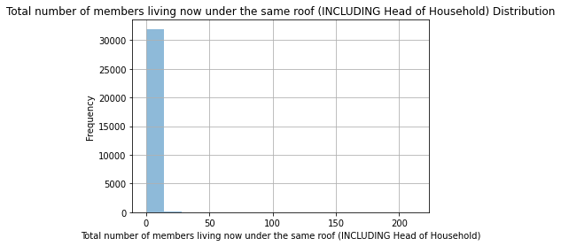

```python
inspect("Total number of members living now under the same roof (INCLUDING Head of Household)")
```

```python
(df["Total number of members living now under the same roof (INCLUDING Head of Household)"]==0).sum()
#1705 values are 0.
```

```
1705
```

## Variable 16: Total number of members over age 60

- A little over 5% of values are missing
- Outliers need to be handled in this column.

```
------------------------------PRINT ALL AND TYPE-----------------------------------
-------------------------------RANGE OF VALUES---------------------------------------
MIN 0.0
MAX 51.0
-------------------------NUMBER OF MISSING VALUES----------------------------------
1684
-------------------------PERCENT OF MISSING VALUES---------------------------------
0.052495401976370835
-------------------------DISTRIBUTION OF VALUES---------------------------------
```

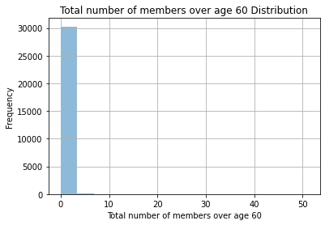

```python
inspect("Total number of members over age 60")
```

## Variable 17: Total number of members between age 18 to 60

- A little over 5% of values are missing
- Outliers need to be handled in this column.

```
------------------------------PRINT ALL AND TYPE-----------------------------------
-------------------------------RANGE OF VALUES---------------------------------------
MIN 0.0
MAX 54.0
-------------------------NUMBER OF MISSING VALUES----------------------------------
1681
-------------------------PERCENT OF MISSING VALUES---------------------------------
0.05240188285170984
-------------------------DISTRIBUTION OF VALUES---------------------------------
```

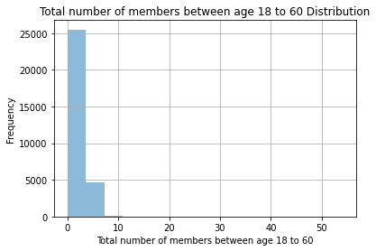

```python
inspect("Total number of members between age 18 to 60")
```

## Variable 18: Total number of members less than 18

- A little over 5% of values are missing
- Outliers need to be handled in this column.

```
------------------------------PRINT ALL AND TYPE-----------------------------------
-------------------------------RANGE OF VALUES---------------------------------------
MIN 0.0
MAX 31.0
-------------------------NUMBER OF MISSING VALUES----------------------------------
1702
-------------------------PERCENT OF MISSING VALUES---------------------------------
0.0530565167243368
-------------------------DISTRIBUTION OF VALUES---------------------------------
```

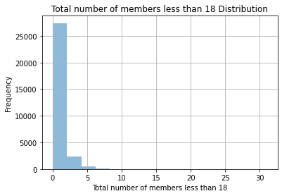

```python
inspect("Total number of members less than 18")
```

## Variable 19: added_members

- Not sure what this column means, especially since the above categories are exhaustive, so this couldnt be an 'other' column.
- Maybe number of members who moved in recently or as a result of the explosion?
- 40% of values are missing
- Values are centered around 3-5.

```
------------------------------PRINT ALL AND TYPE-----------------------------------
-------------------------------RANGE OF VALUES---------------------------------------
MIN 0.0
MAX 28.0
-------------------------NUMBER OF MISSING VALUES----------------------------------
12314
-------------------------PERCENT OF MISSING VALUES---------------------------------
0.38386483369182334
-------------------------DISTRIBUTION OF VALUES---------------------------------
```

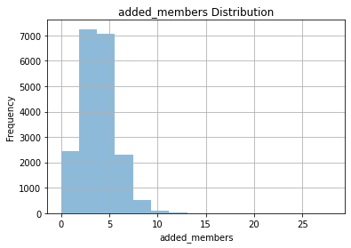

```python
inspect("added_members")
```

## Variable 20: Are any of your family members pregnant or lactating?

- The number of missing values is low (around 5%)

```
------------------------------PRINT ALL AND TYPE-----------------------------------
-------------------------------UNIQUE VALUES---------------------------------------
['no' nan 'yes' 'refuse_to_answer']
---------------------------NUMBER OF UNIQUE VALUES---------------------------------
4
-------------------------NUMBER OF MISSING VALUES----------------------------------
1672
-------------------------PERCENT OF MISSING VALUES---------------------------------
0.05212132547772686
-------------------------DISTRIBUTION OF VALUES---------------------------------
```

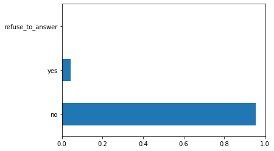

```python
df["Are any of your family members pregnant or lactating?"] = toLowerCase(df, "Are any of your family members pregnant or lactating?")
inspect("Are any of your family members pregnant or lactating?")
```

## Variable 21: Number of pregnant or lactating women

- Some values are 'yes' for are any members pregnant or lactating, but then have 0 for the number.
- Might replace the missing values with 0 or NaN (because those households dont have pregnant or lactating women)

```
------------------------------PRINT ALL AND TYPE-----------------------------------
-------------------------------RANGE OF VALUES---------------------------------------
MIN 0.0
MAX 9.0
-------------------------NUMBER OF MISSING VALUES----------------------------------
30801
-------------------------PERCENT OF MISSING VALUES---------------------------------
0.9601608528944169
-------------------------DISTRIBUTION OF VALUES---------------------------------
```

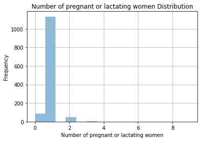

```python
inspect("Number of pregnant or lactating women")
```

```python
df2 = df[["Are any of your family members pregnant or lactating?", "Number of pregnant or lactating women"]]

## They answered yes but then gave a number = 0
#df2 = df2[df2["Are any of your family members pregnant or lactating?"]=='yes']
#df2 = df2[df2["Number of pregnant or lactating women"]==0]

## They said they have no pregnant or lactating, so the second column should be either 0 or NaN for all
df2 = df2[df2["Are any of your family members pregnant or lactating?"]=='no']
df2 = df2[df2["Number of pregnant or lactating women"].notnull()]

len(df2)
df2
```

|  | Are any of your family members pregnant or lactating? | Number of pregnant or lactating women |
| --- | --- | --- |
| 17441 | no | 0.0 |

## Variable 23, 24: Does any of them need woman and child health? (Gynecological support, breastfeeding support, vaccination, etc.) | How many members

- 96% of values are missing, because they don't have a pregnant or lactating woman in the household.
- Only one row has no pregnant or lactating woman but filled out this column, and replied with 'no'.

```
------------------------------PRINT ALL AND TYPE-----------------------------------
-------------------------------UNIQUE VALUES---------------------------------------
[nan 'yes' 'no']
---------------------------NUMBER OF UNIQUE VALUES---------------------------------
3
-------------------------NUMBER OF MISSING VALUES----------------------------------
30873
-------------------------PERCENT OF MISSING VALUES---------------------------------
0.9624053118862808
-------------------------DISTRIBUTION OF VALUES---------------------------------
```

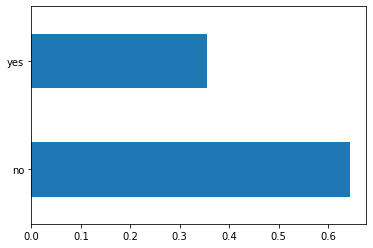

```python
#Make lower
df["Does any of them need woman and child health? (Gynecological support, breastfeeding support, vaccination, etc.)"] = toLowerCase(df, "Does any of them need woman and child health? (Gynecological support, breastfeeding support, vaccination, etc.)")
inspect("Does any of them need woman and child health? (Gynecological support, breastfeeding support, vaccination, etc.)")
```

```
------------------------------PRINT ALL AND TYPE-----------------------------------
-------------------------------RANGE OF VALUES---------------------------------------
MIN 0.0
MAX 7.0
-------------------------NUMBER OF MISSING VALUES----------------------------------
31650
-------------------------PERCENT OF MISSING VALUES---------------------------------
0.986626765173478
-------------------------DISTRIBUTION OF VALUES---------------------------------
```

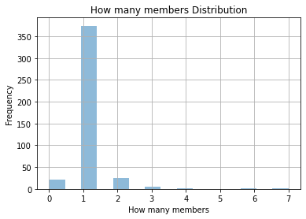

```python
inspect("How many members")
```

```python
df2 = df[["Are any of your family members pregnant or lactating?", "Does any of them need woman and child health? (Gynecological support, breastfeeding support, vaccination, etc.)"]]

## They answered yes but then gave a number = 0
#df2 = df2[df2["Are any of your family members pregnant or lactating?"]=='yes']
#df2 = df2[df2["Number of pregnant or lactating women"]==0]

## They said they have no pregnant or lactating, so the second column should be either 0 or NaN for all
df2 = df2[df2["Are any of your family members pregnant or lactating?"]=='no']
df2 = df2[df2["Does any of them need woman and child health? (Gynecological support, breastfeeding support, vaccination, etc.)"].notnull()]

len(df2)
df2
```

|  | Are any of your family members pregnant or lactating? | Does any of them need woman and child health? (Gynecological support, breastfeeding support, vaccination, etc.) |
| --- | --- | --- |
| 17441 | no | no |

## Variable 25: Are any of the children in the household separated or unaccompanied?

- 43% of values are missing and
- Over 90% of those filled out are 'no', so almost none of the children are separated or unaccompanied.

```
------------------------------PRINT ALL AND TYPE-----------------------------------
-------------------------------UNIQUE VALUES---------------------------------------
[nan 'no' 'yes' 'refuse_to_answer']
---------------------------NUMBER OF UNIQUE VALUES---------------------------------
4
-------------------------NUMBER OF MISSING VALUES----------------------------------
13794
-------------------------PERCENT OF MISSING VALUES---------------------------------
0.4300009351912466
-------------------------DISTRIBUTION OF VALUES---------------------------------
```

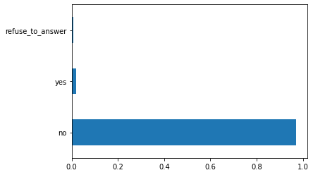

```python
#inspect("Are any of the children in the household separated or unaccompanied?")
#Make lower)
df["Are any of the children in the household separated or unaccompanied?"] = toLowerCase(df, "Are any of the children in the household separated or unaccompanied?")
inspect("Are any of the children in the household separated or unaccompanied?")
```

## Variable 26: Number of separated minors (related to the family, i.e. nephew)

- Over 98% of values are missing. Might replace with 0.

```
------------------------------PRINT ALL AND TYPE-----------------------------------
-------------------------------RANGE OF VALUES---------------------------------------
MIN 0.0
MAX 16.0
-------------------------NUMBER OF MISSING VALUES----------------------------------
31722
-------------------------PERCENT OF MISSING VALUES---------------------------------
0.9888712241653418
-------------------------DISTRIBUTION OF VALUES---------------------------------
```

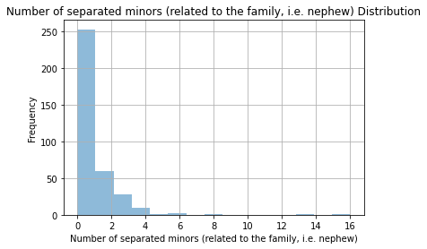

```python
inspect("Number of separated minors (related to the family, i.e. nephew)")
```

## Variable 27: Number of unaccompanied minors (not related, i.e. orphan)

- Over 98% of values are missing. Replace with 0.

```
------------------------------PRINT ALL AND TYPE-----------------------------------
-------------------------------RANGE OF VALUES---------------------------------------
MIN 0.0
MAX 6.0
-------------------------NUMBER OF MISSING VALUES----------------------------------
31723
-------------------------PERCENT OF MISSING VALUES---------------------------------
0.9889023972068954
-------------------------DISTRIBUTION OF VALUES---------------------------------
```

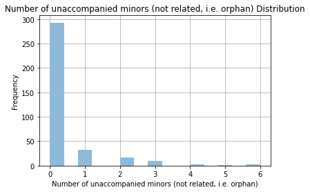

```python
inspect("Number of unaccompanied minors (not related, i.e. orphan)")
```

## Variable 28: Does anyone have a chronic illness or critical medical condition?

```
------------------------------PRINT ALL AND TYPE-----------------------------------
-------------------------------UNIQUE VALUES---------------------------------------
['no' 'yes' nan 'refuse_to_answer']
---------------------------NUMBER OF UNIQUE VALUES---------------------------------
4
-------------------------NUMBER OF MISSING VALUES----------------------------------
1672
-------------------------PERCENT OF MISSING VALUES---------------------------------
0.05212132547772686
-------------------------DISTRIBUTION OF VALUES---------------------------------
```

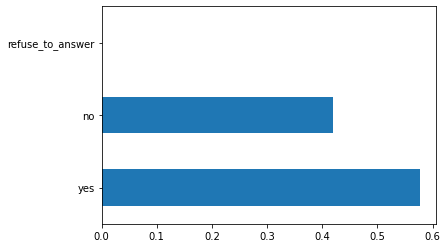

```python
#inspect("Does anyone have a chronic illness or critical medical condition?")
#Make lower
df["Does anyone have a chronic illness or critical medical condition?"] = toLowerCase(df, "Does anyone have a chronic illness or critical medical condition?")
inspect("Does anyone have a chronic illness or critical medical condition?")
```

## Variable 29: Number chronically ill people/with critical medical conditions

- Maybe replace missing values with 0
- Fix outliers.

```
------------------------------PRINT ALL AND TYPE-----------------------------------
-------------------------------RANGE OF VALUES---------------------------------------
MIN 0.0
MAX 11111.0
-------------------------NUMBER OF MISSING VALUES----------------------------------
4470
-------------------------PERCENT OF MISSING VALUES---------------------------------
0.13934349574487984
-------------------------DISTRIBUTION OF VALUES---------------------------------
```

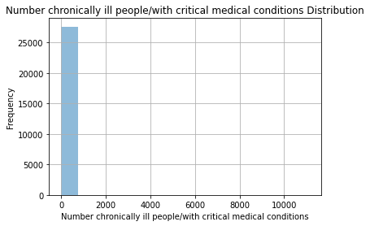

```python
inspect("Number chronically ill people/with critical medical conditions")
```

## Variable 30: Is any member of your family identified with COVID-19 or experienced flu-like symptoms or have been in contact with a COVID-19 positive case in the previous 14 days?

```
------------------------------PRINT ALL AND TYPE-----------------------------------
-------------------------------UNIQUE VALUES---------------------------------------
['no' nan 'yes']
---------------------------NUMBER OF UNIQUE VALUES---------------------------------
3
-------------------------NUMBER OF MISSING VALUES----------------------------------
2984
-------------------------PERCENT OF MISSING VALUES---------------------------------
0.09302035599613455
-------------------------DISTRIBUTION OF VALUES---------------------------------
```

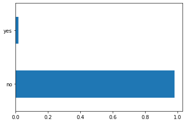

```python
#inspect("Is any member of your family identified with COVID-19 or experienced flu-like symptoms or have been in contact with a COVID-19 positive case in the previous 14 days?")
#Make lower
df["Is any member of your family identified with COVID-19 or experienced flu-like symptoms or have been in contact with a COVID-19 positive case in the previous 14 days?"] = toLowerCase(df, "Is any member of your family identified with COVID-19 or experienced flu-like symptoms or have been in contact with a COVID-19 positive case in the previous 14 days?")
inspect("Is any member of your family identified with COVID-19 or experienced flu-like symptoms or have been in contact with a COVID-19 positive case in the previous 14 days?")
```

## Variable 31: Does anyone have a physical or mental disability?

```
------------------------------PRINT ALL AND TYPE-----------------------------------
-------------------------------UNIQUE VALUES---------------------------------------
['no' 'yes' nan 'refuse_to_answer']
---------------------------NUMBER OF UNIQUE VALUES---------------------------------
4
-------------------------NUMBER OF MISSING VALUES----------------------------------
1674
-------------------------PERCENT OF MISSING VALUES---------------------------------
0.05218367156083419
-------------------------DISTRIBUTION OF VALUES---------------------------------
```

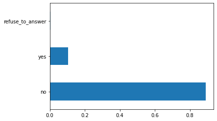

```python
#inspect("Does anyone have a physical or mental disability?")
#Make lower
df["Does anyone have a physical or mental disability?"] = toLowerCase(df, "Does anyone have a physical or mental disability?")
inspect("Does anyone have a physical or mental disability?")
```

## Variable 32: Number with non-disaster related physical and permanent disability

- Remove outliers
- Replace missing values with 0

```
------------------------------PRINT ALL AND TYPE-----------------------------------
-------------------------------RANGE OF VALUES---------------------------------------
MIN 0.0
MAX 13.0
-------------------------NUMBER OF MISSING VALUES----------------------------------
6670
-------------------------PERCENT OF MISSING VALUES---------------------------------
0.20792418716294148
-------------------------DISTRIBUTION OF VALUES---------------------------------
```

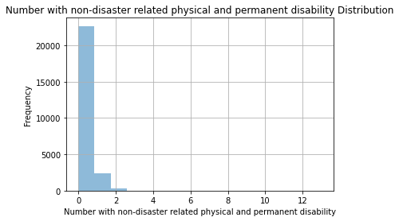

```python
inspect("Number with non-disaster related physical and permanent disability")
```